# From character histories to branch rates and phenomic metrics

This workflow estimates mapped change rates for a combined character or an anatomical group. Each character is first fitted and mapped separately. For each map replicate, its changes are counted on each branch; counts are summed across the selected characters and divided by branch duration. Marginal rates average these branch rates across the sampled lineages present at each age.

The branch-specific estimator retains Sergei Tarasov’s Hymenoptera functions. `branch_rate_pipeline()` adds group handling, normalization, predefined branch comparisons and a consistent final result. It does not require discretizing histories or constructing a stacked-state map.

## Pipeline and function names

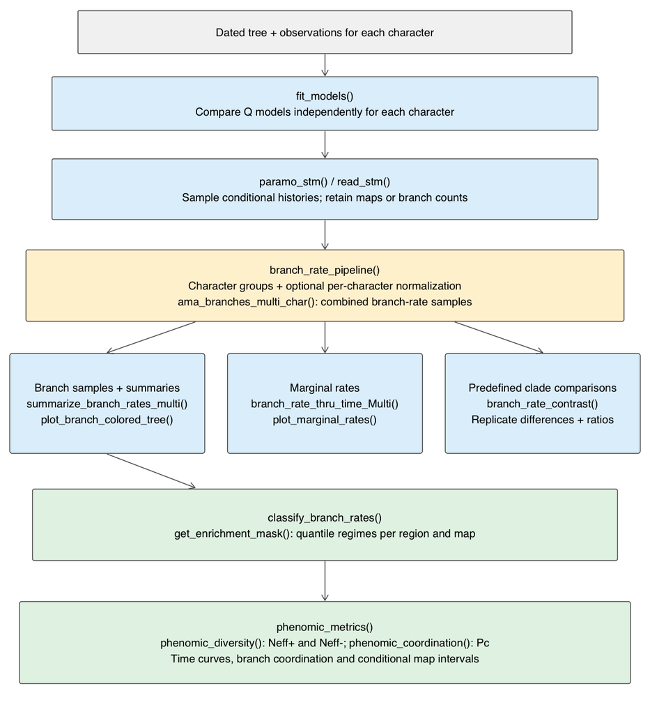

The integrated pipeline. Rate regimes, Neff and Pc are calculated separately for every map replicate before summarizing uncertainty.

The diagram names the public entry points. Internally, the higher-order wrapper summarizes already computed rate samples, so it does not repeat amalgamation. `branch_rate_thru_time_Multi()` calls `branch_rate_thru_time()` separately for each replicate before calculating uncertainty.

| Function | Role |
| --- | --- |
| `fit_models()` | Fit and compare candidate Q models per character. |
| `paramo_stm()` | Sample conditional stochastic histories, optionally in batches on disk. |
| `read_stm()` | Load complete selections of maps from the mapping result. |
| `count_branch_changes()` | Count changes on each branch of one original map. |
| `get_branch_rate_sample_smaps()` | Obtain branch-rate samples for one character. |
| `ama_branches_multi_char()` | Sum branch rates across characters within each replicate. |
| `summarize_branch_rates()` | Summarize a single character across its maps. |
| `summarize_branch_rates_multi()` | Summarize a combined character across its maps. |
| `branch_rate_thru_time()` | Marginalize one branch-rate vector through time. |
| `branch_rate_thru_time_Multi()` | Marginalize all replicates and summarize the curves. |
| `branch_rates()` | Return branch and marginal results for one combined character. |
| `branch_rate_pipeline()` | Run selected anatomical groups, normalization and comparisons. |
| `branch_rate_contrast()` | Compare two predefined, disjoint branch sets within each replicate. |
| `plot_branch_colored_tree()` | Display branch values on a tree. |
| `plot_marginal_rates()` | Display a marginal curve with pointwise map intervals. |
| `get_enrichment_mask()` | Classify unusually high/low rates within a region and map. |
| `classify_branch_rates()` | Obtain both regime arrays, cutoffs and branch classification frequencies. |
| `phenomic_diversity()` | Calculate Neff from whole anatomical regime patterns. |
| `phenomic_coordination()` | Calculate Pc from the mean fraction of accelerated regions. |
| `phenomic_metrics()` | Integrate classification, Neff+, Neff- and Pc through time. |

## Fit models and sample histories

The following small example is executable. The rows identify taxa, and each column is a separate binary character. In this example all characters are variable; inspect the fitting and mapping status tables before analyzing a new dataset. Failed or skipped characters must not disappear silently.

```r
tree <- ape::read.tree(text =
  "(((a:1,b:1):1,(c:1,d:1):1):1,((e:1,f:1):1,(g:1,h:1):1):1);")
characters <- cbind(
  char1 = c("0", "0", "0", "0", "1", "1", "1", "1"),
  char2 = c("0", "0", "1", "1", "0", "0", "1", "1"),
  char3 = c("1", "1", "0", "0", "0", "0", "1", "1"))
rownames(characters) <- tree$tip.label

fits <- fit_models(tree, characters, models = c("ER", "SYM", "ARD"),
                    root_p = "equal", criterion = "AICc", nstarts = 0,
                    seed = 101, on_error = "stop")
fits$status
```

```
#>   character status reason
#> 1     char1     ok
#> 2     char2     ok
#> 3     char3     ok
```

```r
fits$characters$char1$model_table
```

```
#>   model equivalent_to   logLik npar       AIC      AICc    delta    weight
#> 1    ER          <NA> -3.50861    1  9.017219  9.683886 0.000000 0.8660721
#> 2   SYM            ER       NA   NA        NA        NA       NA        NA
#> 3   ARD          <NA> -3.50861    2 11.017219 13.417219 3.733333 0.1339279
#>       status  convergence boundary warnings error
#> 1         ok not_reported    FALSE
#> 2 equivalent not_reported    FALSE
#> 3         ok not_reported    FALSE
```

```r
mapped <- paramo_stm(fits, n_stm = 25, batch_size = 10,
                      seed = 102, on_error = "stop")
mapped$status
```

```
#>   character status n_maps reason
#> 1     char1     ok     25
#> 2     char2     ok     25
#> 3     char3     ok     25
```

```r
maps <- read_stm(mapped)
names(maps)
```

```
#> [1] "char1" "char2" "char3"
```

The same root setting is carried from fitting to mapping. Binary ER and SYM represent the same model and are not fitted twice. Model selection and fixed-Q mapping do not propagate uncertainty in Q or model choice into the subsequent mapping intervals. See the fitting help pages for custom Q index matrices, missing and ambiguous observations, and checkpoint/resumption settings.

If maps were generated elsewhere, supply the same structure directly: `list(char1 = maps_for_char1, char2 = maps_for_char2)`. For example, `phytools::make.simmap()` supplies each character’s map list. These must be the original maps, before discretization or stacked-state amalgamation.

## One call from maps to final outputs

```r
groups <- list(combined = names(maps), region_A = c("char1", "char2"),
                region_B = c("char2", "char3"))
result <- branch_rate_pipeline(maps, groups = groups, normalize = "characters",
                                time_points = seq(3, 0, by = -0.1),
                                time_scale = "age")
result$group_summary
```

```
#>      group n_characters n_maps divisor normalization
#> 1 combined            3     25       3    characters
#> 2 region_A            2     25       2    characters
#> 3 region_B            2     25       2    characters
```

```r
head(result$branch_summary)
```

```
#>      group edge parent child branch_length      mean    median        sd lower
#> 1 combined    1      9    10             1 0.3066667 0.3333333 0.2873893     0
#> 2 combined    2     10    11             1 0.3200000 0.3333333 0.2962731     0
#> 3 combined    3     11     1             1 0.1200000 0.0000000 0.2125681     0
#> 4 combined    4     11     2             1 0.1733333 0.0000000 0.2567604     0
#> 5 combined    5     10    12             1 0.3466667 0.3333333 0.2802116     0
#> 6 combined    6     12     3             1 0.1466667 0.0000000 0.2168802     0
#>       upper
#> 1 1.0000000
#> 2 1.0000000
#> 3 0.6666667
#> 4 0.6666667
#> 5 0.8000000
#> 6 0.6666667
```

```r
head(result$marginal_summary)
```

```
#>      group time n_branches      mean    median        sd     lower upper
#> 1 combined  3.0          2 0.3266667 0.3333333 0.2123502 0.1666667   0.8
#> 2 combined  2.9          2 0.3266667 0.3333333 0.2123502 0.1666667   0.8
#> 3 combined  2.8          2 0.3266667 0.3333333 0.2123502 0.1666667   0.8
#> 4 combined  2.7          2 0.3266667 0.3333333 0.2123502 0.1666667   0.8
#> 5 combined  2.6          2 0.3266667 0.3333333 0.2123502 0.1666667   0.8
#> 6 combined  2.5          2 0.3266667 0.3333333 0.2123502 0.1666667   0.8
```

```r
combined <- result$groups$combined
dim(combined$rate_samples)       # branches x map replicates
```

```
#> [1] 14 25
```

```r
dim(combined$marginal_samples)   # ages x map replicates
```

```
#> [1] 31 25
```

The mapping result can also be passed directly. This reads one character’s branch-count samples at a time and supports disk-backed or count-only runs:

```r
direct <- branch_rate_pipeline(mapped, groups, normalize = "characters",
                                time_points = seq(3, 0, by = -0.1),
                                time_scale = "age")
stopifnot(isTRUE(all.equal(direct$branch_summary, result$branch_summary)))
```

Count-only storage is sufficient for branch-specific and marginal rates, but cannot reproduce the transition times required by stacked-map analyses.

`region_A` and `region_B` overlap in `char2`. They are separate results; they are never summed to produce the combined group. The combined group explicitly contains the three unique characters. A named list returned by `RAC_query()` can be used as `groups` when all of its character IDs occur in `maps`.

With `normalize = "none"`, rates are total character changes per time unit. With `normalize = "characters"`, samples, means, SDs and interval bounds are all divided by the number of characters in their group. This makes units comparable across differently sized groups; it does not correct differences in state spaces or data quality.

## Accelerated and decelerated regimes, Neff and Pc

Select the elementary anatomical regions that define the phenotype. A combined whole-phenome group must not be counted as an additional region alongside its components. The package warns and records shared characters if regions overlap. Here we use three nonoverlapping example groups (one character each); real regions can contain many characters.

```r
anatomy <- list(region_A = "char1", region_B = "char2", region_C = "char3")
phenome <- branch_rate_pipeline(mapped, groups = anatomy,
                                 normalize = "characters", n_points = 25,
                                 phenomic = list(lower_q = 0.05, upper_q = 0.95))
head(phenome$phenomic$summary)
```

```
#>      metric  time n_branches mean median        sd lower upper
#> 1 Neff_plus 3.000          2    1    0.5 0.7071068   0.5     2
#> 2 Neff_plus 2.875          2    1    0.5 0.7071068   0.5     2
#> 3 Neff_plus 2.750          2    1    0.5 0.7071068   0.5     2
#> 4 Neff_plus 2.625          2    1    0.5 0.7071068   0.5     2
#> 5 Neff_plus 2.500          2    1    0.5 0.7071068   0.5     2
#> 6 Neff_plus 2.375          2    1    0.5 0.7071068   0.5     2
```

```r
head(phenome$phenomic$regimes$branch_summary)
```

```
#>      group edge parent child accelerated_frequency decelerated_frequency
#> 1 region_A    1      9    10                  0.40                  0.56
#> 2 region_A    2     10    11                  0.08                  0.92
#> 3 region_A    3     11     1                  0.00                  1.00
#> 4 region_A    4     11     2                  0.00                  1.00
#> 5 region_A    5     10    12                  0.04                  0.96
#> 6 region_A    6     12     3                  0.00                  1.00
#>   both_frequency
#> 1              0
#> 2              0
#> 3              0
#> 4              0
#> 5              0
#> 6              0
```

```r
head(phenome$phenomic$regimes$thresholds)
```

```
#>   map    group lower upper constant n_accelerated n_decelerated n_both
#> 1   1 region_A     0  0.35    FALSE             1            13      0
#> 2   1 region_B     0  1.00    FALSE             3            11      0
#> 3   1 region_C     0  1.00    FALSE             2            12      0
#> 4   2 region_A     0  0.35    FALSE             1            13      0
#> 5   2 region_B     0  1.35    FALSE             1            10      0
#> 6   2 region_C     0  1.35    FALSE             1            10      0
```

The same calculation can be requested after an existing rate analysis. Original maps and disk-backed branch counts give the same result. In either interface, thresholds are recomputed **across all branches within each region and map replicate**, as in `make-Neff-plus.Rmd`, `make-Neff-minus.Rmd` and `make-Pc.Rmd`. They are not pooled across maps, and are not computed separately in each time slice. Positive per-character rate normalization therefore leaves classifications and phenomic metrics unchanged.

```r
regimes <- classify_branch_rates(phenome, lower_q = 0.05, upper_q = 0.95)
dim(regimes$accelerated) # branches x regions x maps
```

```
#> [1] 14  3 25
```

```r
dim(regimes$decelerated)
```

```
#> [1] 14  3 25
```

```r
metrics <- phenomic_metrics(phenome, n_points = 25)
stopifnot(isTRUE(all.equal(metrics, phenome$phenomic)))

# Inspect the rate classification for one map replicate.
one_map <- matrix(0, nrow(tree$edge), length(anatomy),
                    dimnames = list(NULL, names(anatomy)))
for (region in names(anatomy)) {
  one_map[, region] <- phenome$groups[[region]]$rate_samples[, 1]
}
accelerated <- get_enrichment_mask(one_map, 0.05, 0.95, direction = "over")
decelerated <- get_enrichment_mask(one_map, 0.05, 0.95, direction = "under")
accelerated_rates <- get_enrichment_mask(one_map, 0.05, 0.95,
                                         direction = "over", return_type = "masked")
```

These labels describe high and low **relative branch rates**, not acceleration as a derivative along a lineage or a test of a changed Q. Even a homogeneous simulation can have branches in the empirical tails. In particular, a top-5% rule does not recover every branch in a large accelerated clade.

The original directional scripts include rates equal to the cutoff. This is retained with `ties = "include"`; `ties = "exclude"` implements the strict “above/below” language in the manuscript. With many zero rates, inclusive classification can select far more than 5% of branches as decelerated, while a strict lower cutoff of zero selects none. The returned thresholds record actual counts, including overlapping high/low selections when cutoffs coincide. Choose and report the rule; do not silently switch it after inspecting the results.

A constant region is now unclassified by default, and remains in the denominator. Set `constant = "include"` to reproduce the original constant-column behaviour: with inclusive ties it classifies every branch as both high and low. The low-level helper retains its historical 2.5/97.5% defaults, while the integrated functions use the manuscript’s 5/95% defaults. The `"both"` mask is always the union of the two directional masks; the old helper inconsistently used strict cutoffs only for `"both"`.

For a time slice with $N$ branches and $L$ regions, let $E_{b\ell}$ be its 0/1 acceleration pattern. Phenomic coordination (Pc, formerly enrichment strength, $S_e$) is

$$P_c = \frac{1}{N}\sum_{b=1}^N
\frac{1}{L}\sum_{\ell=1}^L E_{b\ell}.$$

All branches are included, including those with no accelerated regions. This matches `make-Pc.Rmd` and `relative_null_metric(type = "scaled")`; the old unscaled helper instead averaged only across enriched branches.

For Neff, let $f^+$ be the fraction of branches with a nonzero pattern and $p_i^+$ the frequencies of distinct **whole binary patterns** among those branches. Then $H^+ = -\sum_i p_i^+\log(p_i^+)$ and $N_{\mathrm{eff}}^+ = f^+\exp(H^+)$. Applying the same formula to the deceleration mask gives $N_{\mathrm{eff}}^-$. When there are no enriched branches, Neff and the effective-pattern count are set to zero. These are pattern-diversity metrics, not entropy over single-region frequencies.

```r
joint <- rbind(c(1, 1), c(0, 0), c(0, 0), c(0, 0))
separate <- rbind(c(1, 0), c(0, 1), c(0, 0), c(0, 0))
phenomic_coordination(joint)       # Pc = 0.25
```

```
#> $Pc
#> [1] 0.25
#>
#> $branch
#> [1] 1 0 0 0
#>
#> $n_lineages
#> [1] 4
#>
#> $n_regions
#> [1] 2
```

```r
phenomic_coordination(separate)    # Pc = 0.25
```

```
#> $Pc
#> [1] 0.25
#>
#> $branch
#> [1] 0.5 0.5 0.0 0.0
#>
#> $n_lineages
#> [1] 4
#>
#> $n_regions
#> [1] 2
```

```r
phenomic_diversity(joint)          # Neff = 0.25
```

```
#>   Neff fraction entropy effective_patterns n_lineages n_enriched n_patterns
#> 1 0.25     0.25       0                  1          4          1          1
```

```r
phenomic_diversity(separate)       # Neff = 1
```

```
#>   Neff fraction   entropy effective_patterns n_lineages n_enriched n_patterns
#> 1    1      0.5 0.6931472                  2          4          2          2
```

Thus Pc measures the extent of accelerated anatomy and can be identical for these distinct co-occurrence patterns. It is not a test of coordination beyond an independence null. Neff distinguishes their whole-pattern diversity.

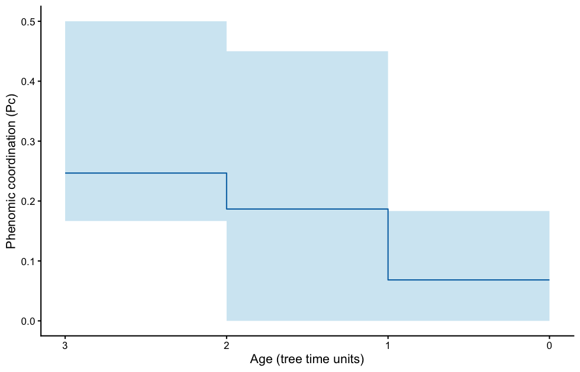

Pc calculated per map and then summarized. The band contains pointwise conditional map quantiles.

```r
pc <- metrics$summary[metrics$summary$metric == "Pc", ]
plot_marginal_rates(pc, ylab = "Phenomic coordination (Pc)")
```

`metrics$samples` retains each time-by-map matrix. `metrics$branch_coordination` retains branch-by-map accelerated-region fractions. The long summary also includes the fraction of enriched lineages, pattern entropy, effective pattern count, and mean fraction of decelerated regions. All-zero rows and constant regions remain in their respective denominators. Nonlinear metrics are computed before averaging maps. Time points and descendant-at-node conventions match marginal rates exactly, including the present.

The uncertainty bands remain conditional mapping intervals. They are not calibrated tests of rate heterogeneity, anatomical dependence or adaptation, and do not incorporate uncertainty in Q, the tree, taxon sampling or region choices. Exact-pattern tests, raw-map/count integration tests and a four-scenario simulation pilot are provided in `inst/validation/phenomic-metrics/`.

## Every lower-level function

For branch b, character c and map replicate m, let N be the reconstructed number of changes and L the branch duration. The combined rate is

$$r_{bm} = \frac{\sum_c N_{bcm}}{L_b}.$$

This estimates a realized mapped change rate, rather than fitting a separate Q matrix to each branch. Reversals are counted. Adjacent segments labelled with the same state do not create a change.

```r
counts <- count_branch_changes(maps$char1[[1]])
head(counts)
```

```
#> [1] 0 0 0 0 0 0
```

```r
one_character <- get_branch_rate_sample_smaps(maps$char1)
head(one_character[[1]])
```

```
#> [1] 0 0 0 0 0 0
```

```r
combined_samples <- ama_branches_multi_char(maps)
head(combined_samples[[1]])
```

```
#> [1] 0 0 0 0 1 1
```

```r
single_mean <- summarize_branch_rates(maps$char1, stat = "mean")
combined_mean <- summarize_branch_rates_multi(maps, stat = "mean")
combined_bounds <- summarize_branch_rates_multi(maps, stat = "quantile",
                                                probs = c(0.025, 0.975))
head(single_mean)
```

```
#> [1] 0.44 0.12 0.00 0.00 0.04 0.00
```

```r
head(combined_mean)
```

```
#> [1] 0.92 0.96 0.36 0.52 1.04 0.44
```

```r
combined_bounds[, 1:4, drop = FALSE]
```

```
#>       [,1] [,2] [,3] [,4]
#> 2.5%     0    0    0    0
#> 97.5%    3    3    2    2
```

For one replicate, the marginal rate is the mean of the rates of branches present at a specified age. The number of contributing branches is returned. It is important to marginalize each replicate first: averaging branch-level interval endpoints does not give the marginal interval.

```r
one_curve <- branch_rate_thru_time(tree, combined_samples[[1]],
                                   time_points = c(3, 2.5, 2, 1, 0),
                                   time_scale = "age")
one_curve
```

```
#>   time rate n_branches
#> 1  3.0 0.50          2
#> 2  2.5 0.50          2
#> 3  2.0 0.75          4
#> 4  1.0 0.25          8
#> 5  0.0 0.25          8
```

```r
curves <- branch_rate_thru_time_Multi(tree, combined_samples,
                                      time_points = seq(3, 0, by = -0.1),
                                      time_scale = "age", return_samples = TRUE)
head(curves$summary)
```

```
#>   time n_branches mean median        sd lower upper
#> 1  3.0          2 0.98      1 0.6370505   0.5   2.4
#> 2  2.9          2 0.98      1 0.6370505   0.5   2.4
#> 3  2.8          2 0.98      1 0.6370505   0.5   2.4
#> 4  2.7          2 0.98      1 0.6370505   0.5   2.4
#> 5  2.6          2 0.98      1 0.6370505   0.5   2.4
#> 6  2.5          2 0.98      1 0.6370505   0.5   2.4
```

```r
one_combined_character <- branch_rates(maps, n_points = 31)
head(one_combined_character$branch_summary)
```

```
#>   edge parent child branch_length mean median        sd lower upper
#> 1    1      9    10             1 0.92      1 0.8621678     0   3.0
#> 2    2     10    11             1 0.96      1 0.8888194     0   3.0
#> 3    3     11     1             1 0.36      0 0.6377042     0   2.0
#> 4    4     11     2             1 0.52      0 0.7702813     0   2.0
#> 5    5     10    12             1 1.04      1 0.8406347     0   2.4
#> 6    6     12     3             1 0.44      0 0.6506407     0   2.0
```

The default `time_scale = "root"` preserves the original interface: supplied times are elapsed from the root. `time_scale = "age"` accepts ages before the present. Returned `time` always means age before the present. At an internal node, descendant branches contribute instead of their ancestor; at the present, terminal branches contribute their limiting rates. Marginal reconstruction requires a rooted ultrametric tree. Branch-only reconstruction is available with `marginal = FALSE`.

## Predefined clade contrasts

Define focal and reference branches before examining inferred rates. The example below compares the terminal branches of two named tip groups. It illustrates the interface, rather than a biological hypothesis about this toy dataset. A real clade comparison can include internal branches as well.

```r
focal_tips <- match(c("a", "b", "c", "d"), tree$tip.label)
reference_tips <- match(c("e", "f", "g", "h"), tree$tip.label)
focal <- which(tree$edge[, 2] %in% focal_tips)
reference <- which(tree$edge[, 2] %in% reference_tips)
comparison <- branch_rate_contrast(combined, focal, reference)
comparison$summary
```

```
#>       metric n_defined n_undefined mean    median        sd      lower
#> 1      focal        25           0 0.14 0.1666667 0.1243502  0.0000000
#> 2  reference        25           0 0.12 0.1666667 0.1319371  0.0000000
#> 3 difference        25           0 0.02 0.0000000 0.1883161 -0.3333333
#> 4      ratio        13          12   NA        NA        NA         NA
#>       upper
#> 1 0.3333333
#> 2 0.3333333
#> 3 0.3333333
#> 4        NA
```

```r
comparison$fraction_focal_greater
```

```
#> [1] 0.4
```

```r
comparisons <- list(left_vs_right = list(focal = focal, reference = reference))
with_contrasts <- branch_rate_pipeline(maps, groups,
                                       normalize = "characters", contrasts = comparisons)
with_contrasts$contrasts$combined$left_vs_right$summary
```

```
#>       metric n_defined n_undefined mean    median        sd      lower
#> 1      focal        25           0 0.14 0.1666667 0.1243502  0.0000000
#> 2  reference        25           0 0.12 0.1666667 0.1319371  0.0000000
#> 3 difference        25           0 0.02 0.0000000 0.1883161 -0.3333333
#> 4      ratio        13          12   NA        NA        NA         NA
#>       upper
#> 1 0.3333333
#> 2 0.3333333
#> 3 0.3333333
#> 4        NA
```

By default, rates within each branch set are weighted by branch duration. The resulting value is total mapped changes divided by total lineage time. `weighting = "equal"` instead treats branches equally. Differences and ratios are calculated within each replicate and then summarized. If a reference rate is zero, its ratio is undefined and this is reported explicitly; differences remain available. There is no automatic pseudocount.

**`fraction_focal_greater` is not a p-value.** The intervals condition on the mapping model. They are not automatically calibrated confidence intervals for generating rate ratios, and selecting high-rate branches from the same result would make a subsequent contrast circular.

## Plot the results

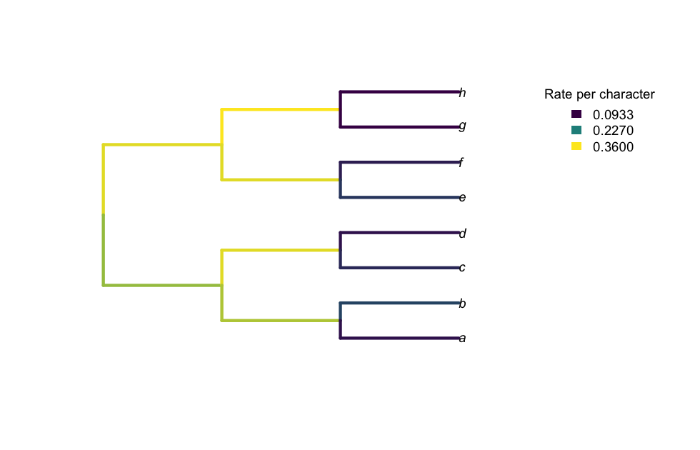

Combined-character branch rates in the example, expressed per character per tree time unit.

```r
plot_branch_colored_tree(combined$tree, combined$branch_summary$mean,
                         legend_title = "Rate per character", edge.width = 3,
                         cex = 0.8)
```

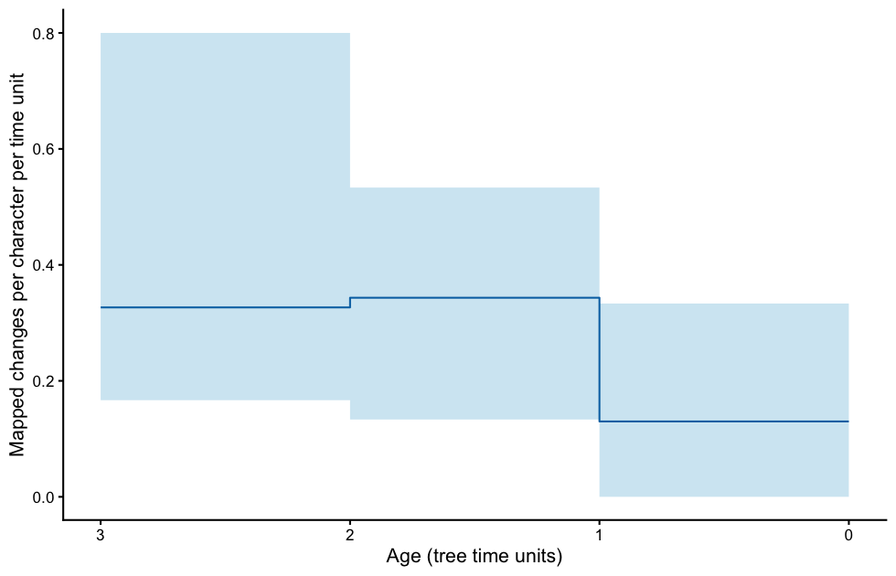

Marginal rates over sampled lineages. Shading is the pointwise central 95% interval across map replicates, conditional on the fitted models and tree.

```r
plot_marginal_rates(combined$marginal_summary,
                     ylab = "Mapped changes per character per time unit")
```

## Rate-heterogeneity validation

The reproducible benchmark is installed with the package in `validation/branch-rates`. It uses the previously specified 100-tip tree with a root age of 150 Ma. The focal 45-tip clade contains 76 whole branches whose parent age is at most 50 Ma; 70 other young branches serve as the reference. Branches crossing 50 Ma retain the baseline rate throughout.

There are 30 independently simulated datasets in each of two conditions, with 20 binary characters per dataset and equal root-state frequencies:

- **Homogeneous control:** q = 0.002 per Myr on every branch.
- **Accelerated clade:** q = 0.020 on focal young branches, and 0.002 elsewhere.

For this downstream benchmark, each character is reconstructed under its own homogeneous ER model fitted with `phytools::fitMk()`, followed by 50 conditional maps from `phytools::make.simmap()`. The same mapping assumptions are used for both conditions. This independent fitting route isolates the downstream estimator; the executable example above separately tests the package’s `fit_models()` and `paramo_stm()` interface.

The simulator uses the exact symmetric-binary construction: Poisson event counts, uniformly distributed event times conditional on the count, and state flips inherited along the tree. Its event means and endpoint-state frequencies are checked against the analytic Mk distribution. True histories are retained to distinguish simulation/accounting correctness from inference using only tip observations. All characters, including invariant tip patterns, are retained in the benchmark. No histories are selected for favourable recovery. Unidentified high-rate fitting plateaus stop a run with saved diagnostics rather than triggering silent character removal.

| Condition | Datasets | Median AUC | Median ratio | Interval excludes equal rates | Interval covers true ratio |
| --- | --- | --- | --- | --- | --- |
| Homogeneous | 30 | 0.498 | 1.03 | 9/30 | 21/30 |
| 10-fold acceleration | 30 | 0.914 | 4.10 | 30/30 | 0/30 |

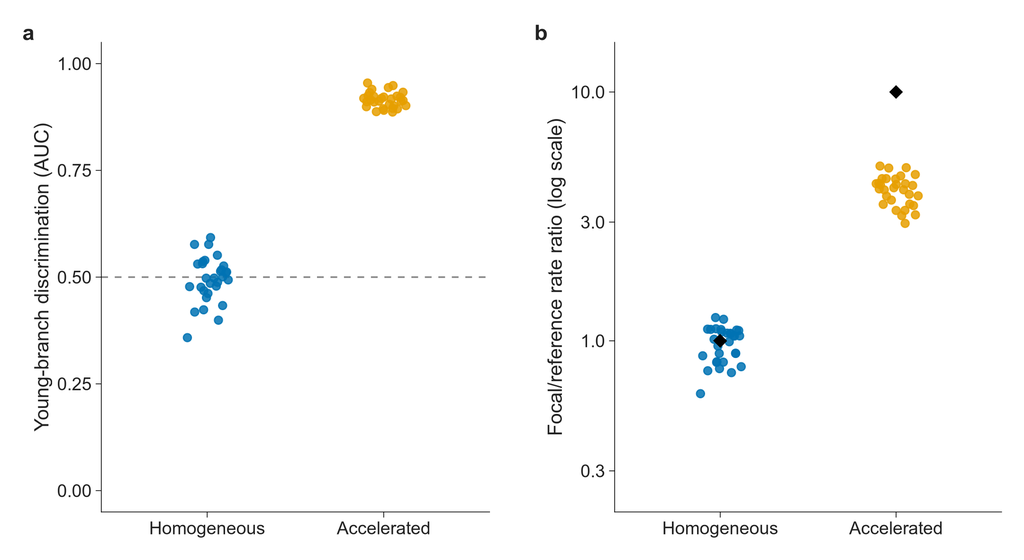

Validation on the fixed 100-tip tree. Each point represents one independently simulated character dataset. AUC describes discrimination between focal and reference young branches; it is not a branch-wise significance test.

The validation report separates branch-ranking discrimination, recovered fold change, coverage of the generating ratio, and the frequency with which the conditional mapping interval excludes equal rates under the homogeneous control. These are distinct properties. Good localization can coexist with substantial attenuation of the generating fold increase.

In the homogeneous control, the conditional interval excluded equal rates in 9/30 datasets. Under a true ten-fold acceleration, the median inferred ratio was 4.1 and the median AUC was 0.914; the interval covered the generating ratio in 0/30 datasets. Thus the method localized the strong accelerated regime in this design, but its conditional mapping intervals are unsuitable as nominal 5% tests of underlying rate heterogeneity or as calibrated intervals for the generating fold change.

The fixed-tree benchmark does not establish robustness to incomplete taxon sampling, phylogenetic error or polytomies. Nor does it measure adaptation or provide a calibrated discovery test for unknown accelerated branches. The number of simulated datasets is too small to establish precise tail error rates; raw results and their counts are supplied for interpretation.

To rerun the benchmark, copy its installed directory into a writable folder and run `Rscript --vanilla run-validation.R`. Optional arguments specify the output directory, datasets per condition and maps per character. Environment variables `ONTO_FIRST_DATASET` and `ONTO_LAST_DATASET` allow disjoint chunks; seeds are independent of worker scheduling and completed datasets are reused.

## Phenomic-metric validation

The new four-scenario pilot uses the same fixed 100-tip tree, two nonoverlapping regions of ten binary characters, equal root-state frequencies and 25 conditional maps per character. It uses the actual `fit_models()` -> `paramo_stm()` -> `branch_rate_pipeline(phenomic = list())` route. No taxa or characters are dropped. Each scenario is one prespecified dataset, so these are smoke tests, not estimates of power or interval coverage.

The conditions are homogeneous rates (0.002/Myr); coordinated tenfold acceleration in the same focal young clade for both regions; mosaic tenfold acceleration in different young clades; and tenfold deceleration in the focal clade for both regions. The generating rate vectors are classified using the same quantile rule as the realized and reconstructed event rates. These three targets differ even when the actual histories are known, because finite event counts are noisy and may include many zeros.

| Scenario | Classified fraction | Regime AUC | Precision | Present Pc |
| --- | --- | --- | --- | --- |
| homogeneous | 0.051 | NA | NA | 0.051 |
| coordinated | 0.051 | 0.695 | 0.921 | 0.070 |
| mosaic | 0.051 | 0.677 | 0.900 | 0.073 |
| decelerated | 0.837 | 0.707 | 0.451 | 0.043 |

For the two accelerated scenarios, about 90–92% of accelerated calls fall in truly elevated-rate branches. However, the 5% tail captures only a subset of a much larger shifted clade; AUC based on classification frequency is only about 0.68–0.70. Under homogeneous rates, about 5% of branch-region entries are still classified as accelerated. These calls are empirical tails, not null rejections. In the decelerated scenario, inclusive ties classify about 84% as slow because of zero event counts; a strict lower cutoff selects none in these pilots. Neither rule alone establishes calibrated detection of deceleration.

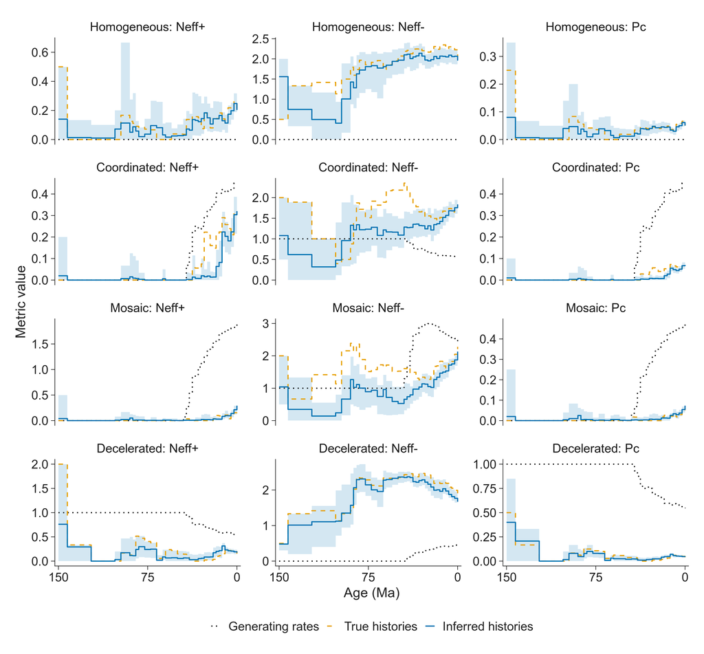

Four fixed simulation pilots. Dotted black curves classify generating rates, dashed orange curves classify the actual histories, and blue curves/bands summarize reconstructed histories (95% conditional map quantiles). All use the same inclusive quantile rule; constant columns are unclassified. These are distinct targets, and the reconstruction does not recover the generating Neff/Pc magnitudes.

Exact-pattern unit tests separately verify the formulas, including identical Pc but different Neff for coordinated versus dispersed patterns. One hundred fixed-seed compatibility cases reproduce the original directional masks, Neff, and scaled Se/Pc. Thus the implementation is numerically validated, but these pilots do not validate Neff/Pc as unbiased estimates of latent regime structure. The executable scripts, settings, full results and sensitivity table are in `inst/validation/phenomic-metrics/`.

## Input and uncertainty checks

- All characters must share the tree, tip labels, edge order, branch lengths and map sample size. Edge order is checked, not silently inferred.
- Branch lengths and mapped segment durations must be positive. Segment durations must sum to their corresponding branch length.
- Map replicate identities are retained through amalgamation, normalization, comparisons and marginalization. Independently sampled character histories can be paired by position; dependent characters require joint draws.
- Fixed-Q mapping intervals exclude uncertainty in fitted Q, model choice, topology, dating and taxon sampling. A larger number of maps reduces Monte Carlo error but does not remove those limitations.